# e2219277-H5

Behiye Alak

2021-02-01

*The Relationship between Life Expectancy and Education Level*

*Average life expectancy increases every year. The development level of the country’s economy plays a role in this increase and the education levels of developed economies are also high. On the other hand, education level also has an effect on life expectancy. In this article, our aim is to examine the relationship between life expectancy and education level.*

*First, in economically developed countries people live longer. This is not just because of the money also because of the education level. The reason for this is that before someone has attained their life expectancy, schooling happens, and it changes the life expectancy. More education results in more wealth, and since everything people need to stay healthy - from food to medical care - costs money, wealth increases life expectancy. At the same time, education provides better planning and self-control throughout the rest of their life by improving their cognitive abilities. As a result, education increases wealth and life expectancy.*

*When we look at the two graphs, we can see the positive relationship between education level and life expectancy. If a country has a developed economy, the level of education also increases, thus increasing life expectancy. If a country’s education level is high, its life expectancy increases even if it does not have a developed economy. However, it is very difficult for a country to increase its life expectancy before its education level increases.*

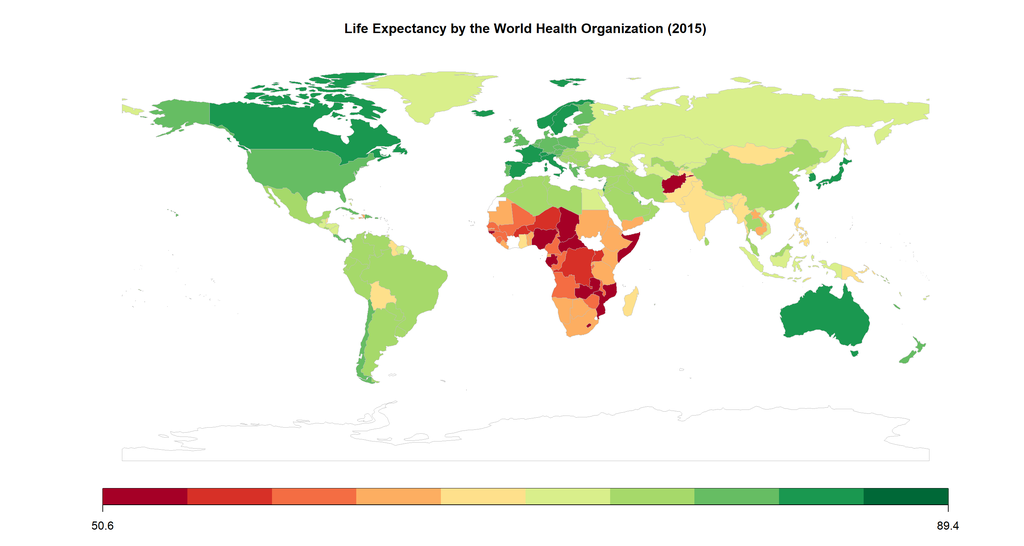

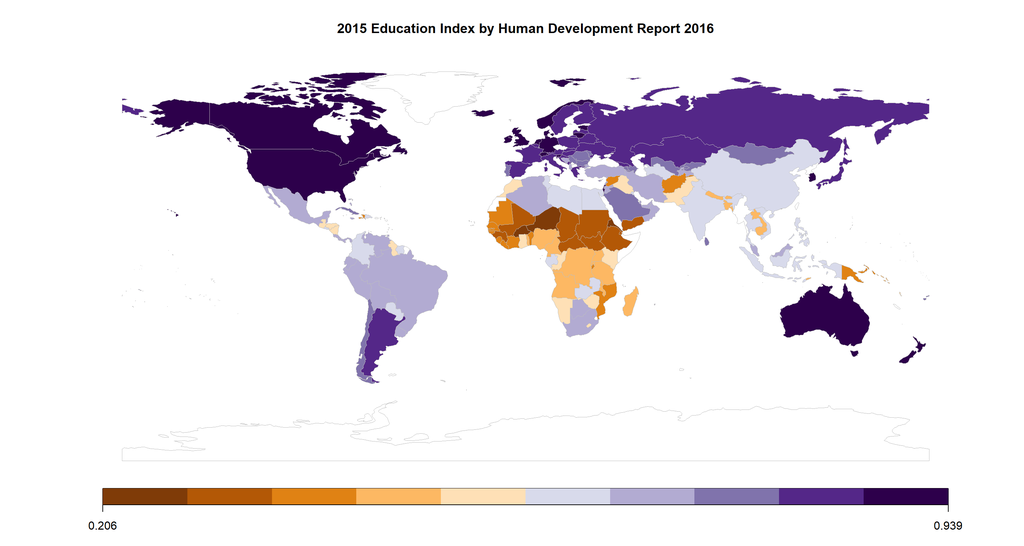

Appendix:

```r
library(rvest)
library(ggplot2)
library(data.table)
library(stargazer)
library(ggmap)
library(tmaptools)
library(RColorBrewer)
library(rworldmap)

#For life expectancy data
rhtml <- read_html("https://en.wikipedia.org/wiki/List_of_countries_by_life_expectancy")

rtables <- html_nodes(rhtml, "table")
rtables

lifetable <- html_table(rtables[16], header = T, dec = ".", fill=TRUE)
lifetable
class(lifetable)

lifedata <- lifetable[[1]]
lifedata  <- lifedata[,c(1,4)]


colnames(lifedata)[colnames(lifedata) == "Both"] <- "Life Expectancy by the World Health Organization (2015)"

worldmap1 <- joinCountryData2Map(lifedata ,
                                 nameJoinColumn = "Country",
                                 joinCode = "NAME")

colorpalette1 <- RColorBrewer::brewer.pal(10, "RdYlGn")

map1 <- mapCountryData(worldmap1,
               nameColumnToPlot = "Life Expectancy by the World Health Organization (2015)",
               catMethod = "fixedwidth",
               colourPalette = colorpalette1,
               numCats = 10)

#For education index
phtml <-  read_html("https://en.wikipedia.org/wiki/Education_Index")

ptables <- html_nodes(phtml, "table")
ptables

ptable1 <- html_table(ptables[2], header = T, dec = ".", fill=TRUE)
class(ptable1)

educationtable <- ptable1[[1]]
educationtable <- educationtable[, c(2,3)]

colnames(educationtable)[colnames(educationtable) == "EducationIndex"] <- "2015 Education Index by Human Development Report 2016"

worldmap2 <- joinCountryData2Map(educationtable ,
                                 nameJoinColumn = "Country",
                                 joinCode = "NAME")

colorpalette2 <- RColorBrewer::brewer.pal(10, "PuOr")

map2 <- mapCountryData(worldmap2,
               nameColumnToPlot = "2015 Education Index by Human Development Report 2016",
               catMethod = "fixedwidth",
               colourPalette = colorpalette2,
               numCats = 10)

map1 <- mapCountryData(worldmap1,
               nameColumnToPlot = "Life Expectancy by the World Health Organization (2015)",
               catMethod = "fixedwidth",
               colourPalette = colorpalette1,
               numCats = 10)
map2 <- mapCountryData(worldmap2,
               nameColumnToPlot = "2015 Education Index by Human Development Report 2016",
               catMethod = "fixedwidth",
               colourPalette = colorpalette2,
               numCats = 10)
```